# 第12回 主成分分析の解析例：論文のコードを読む

論文のコードを読んで、動かす

# 導入

## ここまでは、自分で書いた

- 第9回〜第11回：PCAで縮め、地図に置き、グループに分けた
- どれも、自分で書いたコード

## 今日は、研究者のコードを読む

- 論文といっしょに公開されたコードを読む
- 題材は、ハッブル宇宙望遠鏡が撮った銀河の画像

## 場面：天文学の研究室

- あなたは、天文学の研究室に入ったばかりの新人
- 先輩から、銀河の形を調べた論文を1本渡された
- 「この論文のコードを動かして、主張が本当か確かめておいて」

## 決めたいこと

- 論文の主張が、手元で動かしても成り立つかを確かめたい
- 著者のコードのどこが、その主張を確かめているのかを知りたい

## 論文の主張

- Uzeirbegovic, Geach, Kaviraj（2020, MNRAS）
- 「銀河の形は、十数枚の固有銀河の足し算で表せる」
- 固有銀河：銀河の画像の主成分（第9回の固有顔の、銀河版）

## 手元のデータ

- 著者がGitHubに公開したリポジトリから、ノートと画像を取ってくる
- ハッブル宇宙望遠鏡が撮った銀河の画像、1,222個ぶん
- 1個が30×30画素で、3つの波長の帯。答えの列はない

## データをのぞく

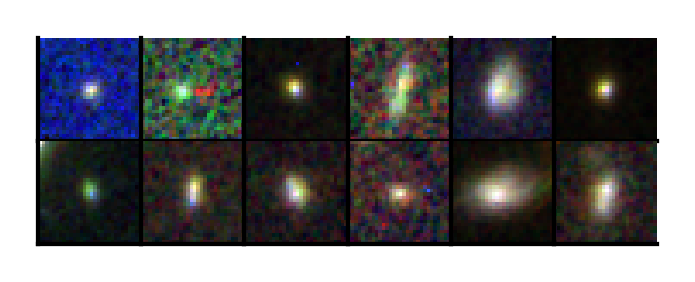

- 1枚が1つの銀河。人が見るために色をつけた画像

## 最後に出す答え

- 固有銀河いくつで、銀河の形の何%を表せるか。論文の数と比べる
- 似た形の銀河を集めると、どんなグループに分かれるか

## 今日の問い

著者のコードを読んで動かし、「十数枚の固有銀河で表せる」を手元で確かめられるか？

## もう1つのねらい：研究のコード

- 他人の研究のコードを、ブロックに分けて読み、動かせるようになる
- ノート（`.ipynb`）の中身を、JSONとして読む
- たくさんのファイルを集め、形式ごとに読む

## この問いに、どう近づくか

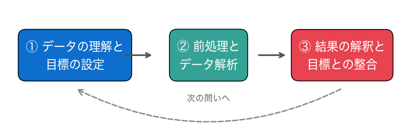

他人の解析の①〜③を、コードから読み解きます。

# 0. 設定

## コードとデータを、取ってくる

```python
WORK = '/content'   # Colab の作業場所
URL = 'https://github.com/emiruz/eigengalaxies.git'
PICK = ("'/Eigengalaxies.ipynb' '/CANDELS/GDS_[12]???.npy' "
        "'/GDS_RGBs/GDS_0[12]???.png'")      # 取ってくるファイルの型
os.chdir(WORK)
if not os.path.exists('eigengalaxies'):     # まだ取ってきていなければ
    !git clone -q --depth 1 --filter=blob:none --sparse $URL
    !cd eigengalaxies && git sparse-checkout set --no-cone {PICK}
os.chdir('eigengalaxies')                   # ここを作業の場所にする
print(sorted(os.listdir('.')))
```

## 必要なファイルだけ、取ってくる

- リポジトリ全体は400MB以上
- `git`の機能で、ノートと銀河1,222個ぶんだけ取ってくる（数秒・約40MB）

## ! で始まる行

```python
    !git clone -q --depth 1 --filter=blob:none --sparse $URL
```

- `!`で始まる行は、Pythonではなく、計算機に直接出す命令
- `$URL`や`{PICK}`で、Pythonの変数を命令の中に入れられる

## os.chdir：作業の場所を移す

```python
os.chdir('eigengalaxies')                   # ここを作業の場所にする
```

- `os.chdir`：作業の場所（フォルダ）を移す関数
- 著者のコードは、このフォルダの中で動く前提

## やってみよう：0節

- 第12回のノートを開き、ドライブにコピーする
- 0節の2つのセルを実行する

動画の人は、ここで一時停止。

## 答え合わせ：3つがそろった

```
['CANDELS', 'Eigengalaxies.ipynb', 'GDS_RGBs']
```

- `CANDELS`：銀河の画像の数値、`GDS_RGBs`：カラーの縮小画像
- `Eigengalaxies.ipynb`：著者のノート

# 1. 論文とコードの地図

## 3つがそろった。どこから読む？

- まずは、著者のノート`Eigengalaxies.ipynb`

## いきなり1行目から、読まない

- まず、どんなまとまり（ブロック）が、どの順に並んでいるかをつかむ
- 地図を描いてから、ブロックごとに読む

## ノートは、JSONという形式

- `.ipynb`は、JSONという形式の文字のファイル
- JSON：辞書`{名前: 値}`とリスト`[…]`を入れ子にして書く形式

## おさらい：辞書

```python
d = {}
for i in range(3):
    d[i] = i * 10        # d は {0: 0, 1: 10, 2: 20}
```

- キーと値の組を覚えておく入れ物。`d[キー]`で取り出す（第3回）

## お手本：JSONとして読む

```python
nb = json.load(open('Eigengalaxies.ipynb'))   # ノートの中身は JSON
print(list(nb.keys()))
print(len(nb['cells']), 'セル')
print(nb['cells'][2])                         # 2番目のセルの中身
```

- 役割：著者のノートを開き、中身がどんな形かを見る

## json.loadとopen

```python
nb = json.load(open('Eigengalaxies.ipynb'))   # ノートの中身は JSON
```

- `open`：ファイルを開く
- `json.load`：開いたJSONを、辞書とリストに直して読む

## おさらい：forとif

```python
for i in range(3):
    if i > 0:
        print(i)      # 1, 2 と表示される
```

- `for`：並びの中身を1つずつ名前に入れながら、繰り返す
- `if`：条件が成り立つときだけ実行する（第2回）

## 変えてみる：見出しだけを並べる

```python
for i, cell in enumerate(nb['cells']):
    if cell['cell_type'] == 'markdown':
        print(i, ''.join(cell['source']).strip()[:40])
```

- 文章のセル（markdown）だけを取り出し、先頭の40字を表示する

## ’’.joinとstrip

```python
        print(i, ''.join(cell['source']).strip()[:40])
```

- `''.join(リスト)`：行ごとに分かれた文字を、1つの文字につなげる
- `.strip()`：前後の空白や改行を取り除く

## TODO①：コードのセルの1行目

```python
# TODO: コードのセルの番号と、1行目を表示する
# ヒント: if cell['cell_type'] == 'code': の中で
#         cell['source'][0] が1行目（改行は .strip() で消す）
...
```

## やってみよう：1節とTODO①

- 1節のお手本と「変えてみる」のセルを実行する
- TODO①：コードのセルの、1行目を並べる

動画の人は、ここで一時停止。

## 答え合わせ：辞書とリスト

```
['cells', 'metadata', 'nbformat', 'nbformat_minor']
35 セル
{'cell_type': 'markdown', 'metadata': {}, 'source': ['# Constants']}
```

## セルも、辞書

- `'cells'`に、セルが35個、リストで入っている
- 1つのセルも辞書で、`'cell_type'`と`'source'`（中身の行のリスト）を持つ

## 答え合わせ：見出しの並び

```
0 # Common imports
2 # Constants
4 # Data Processing Functions
6 # Image Generation
8 # Data
10 # PCA
13 # Checks
15 # Outlier Detection
17 # Sample size, eigengalaxies, and explai
19 # Cumulative sum of explained variance.
21 # Reconstruction Error
23 # The Eigengalaxies
25 # Imputing Values
29 # Image Query
30 Example generator for image queries.
32 # Affinity Propagation Clustering
```

## ノートの地図

| セル | 見出し | 今日 |
| --- | --- | --- |
| 1・3 | 道具と定数 | 使う |
| 5・7 | 前処理の関数／画像を並べる関数 | 使う |
| 9・11 | Data／PCA | 使う |
| 14・18 | PCAを何百回もくり返す確認 | 重いので飛ばす |
| 16 | 外れ値 | 使う |
| 24 | 固有銀河 | 使う |
| 26 | 欠けた値の補い | 別の道具が要るので飛ばす |
| 33 | クラスタリング | 使う |

## 答え合わせ：TODO①

```
1 import re,os                      3 SHP=(30,30,3)
5 def rescale(a):                   7 import matplotlib.image as mpi
9 raw_data,indexes=get_data()       11 pca=PCA(.96).fit(norm_data)
12 examples=[0,6,10,11,24,33,43,4   14 k=12
16 lik_idx=indexes[np.argsort(lik   18 L=[]
20 pca_all=PCA().fit(norm_data)     22 recon_data=np.dot(scores,pca.c
24 L=[]                             26 from pyppca import ppca
27 Example generation               28 norm_samp=norm_data[inc_idx]
31 np.random.seed(1)                33 from sklearn.cluster import Af
34 import os
```

- コードのセルは19個（2列に並べて表示）

## 1行目で、ブロックが見分けられる

- `def rescale(a):`（5）→ 関数を作るブロック
- `raw_data,indexes=get_data()`（9）→ それを使うブロック

## 写さずに、取り出して実行する

- 著者のコードを打ち直すと、写し間違える
- ノートのJSONから、セルの中身を取り出してそのまま実行する

## お手本：読んでから、実行する

```python
def author(i):                       # i 番目のセルの中身
    return ''.join(nb['cells'][i]['source'])

print(author(3))                      # 定数のセルを読む
exec(author(1))                       # 道具を呼び出すセルを実行
exec(author(3))                       # 定数のセルを実行
print(SHP, BANDS)
```

## おさらい：def

```python
def 名前(引数):
    return 戻り値
```

- `def`の後ろが名前と引数（入力）、`return`の後ろが戻り値（出力）（第3回）

## exec：文字のコードを実行する

```python
exec(author(1))                       # 道具を呼び出すセルを実行
```

- `exec`：文字で書かれたコードを、その場で実行する
- `print(author(i))`で読み、`exec(author(i))`で実行

## 答え合わせ：定数

```
SHP=(30,30,3)
BAND_ORDER=[2,0,1]
BANDS=["F814W","F125W","F160W"]
(30, 30, 3) ['F814W', 'F125W', 'F160W']
```

- `SHP`：1つの銀河の大きさ。縦30×横30画素×3つの色の帯
- `BANDS`：望遠鏡が撮った、3つの波長の帯

# 2. 読み込み

## 地図はできた。データはどう読む？

- 使うのは、5番のセルの`get_data`

## データは、2つの形式

- `CANDELS/GDS_1000.npy`：numpyの配列をそのまま保存した .npy
- `GDS_RGBs/GDS_01000.png`：ふつうの画像のPNG

## お手本：2つの形式で読む

```python
x = np.load('CANDELS/GDS_1000.npy', allow_pickle=True)
im = plt.imread('GDS_RGBs/GDS_01000.png')
print(x.shape, x.dtype, x.min().round(3), x.max().round(3))
print(im.shape, im.dtype, im.min(), im.max())
```

- 役割：同じ銀河を2つの形式で読み、大きさと値の範囲を比べる

## 形式ごとに、読む関数が違う

- `.npy`は`np.load`
- PNGは`plt.imread`
- `allow_pickle=True`：Pythonのものを含んで保存された .npyも読む指定

## 変えてみる：globで集める

```python
files = glob('CANDELS/*.npy')
print(len(files))
print(files[:3])
```

- `glob('CANDELS/*.npy')`：`*`に何が入ってもよい、という型に合うファイルの名前をすべて集める

## お手本：get_dataを読む

```python
print(author(5)[author(5).index('def get_data'):
                  author(5).index('def get_catalog')])
```

- 5番のセルから、`get_data`の部分だけを切り出して読む
- `.index('…')`：その文字が何文字目にあるか

## お手本：読んで、並べ直す

```python
exec(author(5))                        # 前処理の関数を作る
raw_data, indexes = get_data()
order = np.argsort(indexes)            # 名前の順に並べる順番
raw_data, indexes = raw_data[order], indexes[order]
print(raw_data.shape, indexes[:3])
```

## おさらい：[ ] の中のfor

```python
out = [i * 10 for i in range(3)]   # out は [0, 10, 20]
```

- 1つずつ式を計算して、結果をリストに集める（内包表記、第5回）

## TODO②：外す条件を、確かめる

```python
# TODO: x の3つの帯の最大が0かどうかと、標準偏差が0でないかを表示する
# ヒント: [x[:, :, i].max() == 0 for i in range(3)]、x.std() != 0
...
```

## やってみよう：2節とTODO②

- 2節のお手本と「変えてみる」のセルを実行する
- TODO②：`get_data`が外す条件を、1つの銀河で確かめる

動画の人は、ここで一時停止。

## 答え合わせ：同じ大きさ、違う中身

```
(30, 30, 3) float32 -0.015 0.185
(30, 30, 3) float32 0.0 1.0
```

- どちらも30×30×3の配列

## 測った値と、見るための絵

- .npy：望遠鏡が測った明るさの数値そのもの（マイナスもある）
- PNG：人が見るために0〜1に直したカラー画像
- 解析には .npy、目で見るにはPNG

## 答え合わせ：glob

```
1222
['CANDELS/GDS_1112.npy', 'CANDELS/GDS_1106.npy', 'CANDELS/GDS_2369.npy']
```

- 1,222個。でも、`GDS_1000`の順に並んでいない

## globの順番は、変わる

- `glob`が返す順番は、計算機やファイルの置かれ方で変わることがある
- 順番が変わると、あとの結果の並びも変わってしまう

## get_dataの中身

```
def get_data():
    L=[]
    def f(x): return re.search("[^/]+(?=.npy)",x)[0]
    fns=[x for x in map(f,glob("CANDELS/*.npy"))]
    skip=[]
    for fn in fns:
        x=np.load("CANDELS/%s.npy" % fn,allow_pickle=True)
        skip.append(any([x[:,:,i].max()==0 for i in range(0,SHP[2])]))
        L.append(x.flatten())
    a=np.row_stack(L)
    I=(a.std(axis=1)!=0) & ~(np.array(skip))
    return a[I],np.array(fns)[I]
```

## ブロック①：名前を集める

- `glob`で .npyのファイルを集める
- `re.search`で、`GDS_1000`のような名前の部分を取り出す（`re`は文字の型で探す道具）

## ブロック②：1つずつ読む

- `for`で1つずつ`np.load`し、`flatten()`で2,700個（30×30×3）の横一列に
- 3つの帯のどれかが真っ暗（最大が0）なら、`skip`に記録

## ブロック③：表にして、外す

- `np.row_stack(L)`：横一列を縦に積んで表にする
- 明るさが一様（標準偏差が0）なものと、`skip`のものを外す

## ブロック④：返す

- 表と、名前の並びを返す
- 4つのブロックに分ければ、12行の関数も読める

## 1段足して、並べ方をそろえる

```python
order = np.argsort(indexes)            # 名前の順に並べる順番
raw_data, indexes = raw_data[order], indexes[order]
```

- `np.argsort`：並べ替えたときの順番（番号）を返す
- 著者のコードに手を入れず、こちらで1段足す

## 答え合わせ：1,222行の表

```
(1222, 2700) ['GDS_1000' 'GDS_1001' 'GDS_1003']
```

- 1行が1つの銀河。この1,222個では、外された銀河はなかった

## 答え合わせ：TODO②

```
[np.False_, np.False_, np.False_]
True
```

- どの帯も真っ暗ではなく、ばらつきもある。外されない

## 機械的に、失敗を除く

- 撮影の失敗で、一部の帯が写っていない画像
- 著者は、こうした画像を条件で機械的に除いていた

# 3. 前処理

## 読めた。PCAの前に何をする？

- 9番のセルは、PCAの前に`normalise_all`を呼ぶ

## normalise_allがする、2つのこと

- 明るさのクリップ：0%点〜99%点の外を、その値に切りそろえる
- 回転をそろえる：伸びている向きを求め、同じ向きに回す

## なぜ、そろえるのか

- クリップ：ごく一部の、とても明るい画素に引っぱられないため
- 回転：向きだけ違う同じ形を、「違う形」と数えないため

## お手本：前と後を並べる

```python
exec(author(7))                          # 画像を並べる関数を作る
norm_data = normalise_all(raw_data, 0, .99)
make_image_pre(raw_data[:9].copy(), (3, 3), '前')   # 写しを渡す
make_image_pre(norm_data[:9].copy(), (3, 3), '後')
plt.show()
```

## なぜ、写しを渡すのか

- `make_image_pre`は、描く前に`r-=r.min()`と、受け取った配列をその場で書きかえる
- 表の一部をそのまま渡すと、元の表まで書きかわる

## 書きかわると、結果が変わる

- 実際に試すと、あとのPCAの主成分の数が10個 → 12個に変わる
- 他人の関数は、渡したものを書きかえないかを読んで確かめる

## 回転の角度は、PCAで測る

```python
def get_angle(d):
    fit=PCA(n_components=2).fit(
        np.argwhere(d>=np.quantile(d,.75)))
    return np.arctan2(*fit.components_[0])
```

## np.argwhere：明るい画素の座標

- `np.quantile(d, .75)`：明るさの75%点
- `np.argwhere(条件)`：条件がTrueの所の座標（縦・横の番号）を集める

## 座標の点に、PCAをかける

- 第1主成分は、点がいちばん長く散らばる向き＝銀河の伸びる向き
- `np.arctan2`：その向きを角度に直す

## 変えてみる：1つの銀河の角度

```python
gal = np.load('CANDELS/GDS_1601.npy', allow_pickle=True)  # 細長い銀河
fl = np.apply_along_axis(max, 2, gal)
print(round(np.degrees(get_angle(fl)), 1))
```

- `np.apply_along_axis(max, 2, …)`：画素ごとに、3つの帯のいちばん明るい値を取る
- `np.degrees`：角度を度に直す

## 変えてみる：全部の銀河で比べる

```python
def angle(row):                      # 1つの銀河の、伸びた向き（度）
    fl = np.apply_along_axis(max, 2, row.reshape(SHP))
    return np.degrees(get_angle(fl))

before = np.abs([angle(r) for r in raw_data])
after = np.abs([angle(r) for r in norm_data])
print(np.median(before).round(1), np.median(after).round(1))
```

## 1行ずつ、角度を測る

```python
before = np.abs([angle(r) for r in raw_data])
```

- `[angle(r) for r in raw_data]`：1行（1つの銀河）ずつ角度を測り、リストに集める
- `np.abs`：絶対値。向きなので、符号は見ない

## やってみよう：3節

- 3節のお手本と「変えてみる」のセルを実行する
- 前処理で、銀河はどう変わるか？

動画の人は、ここで一時停止。

## 答え合わせ：前と後

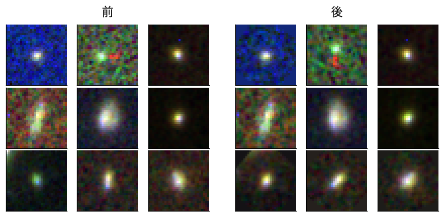

- 前処理の前（左）と後（右）の、同じ9個

## 伸びた銀河が、縦に回った

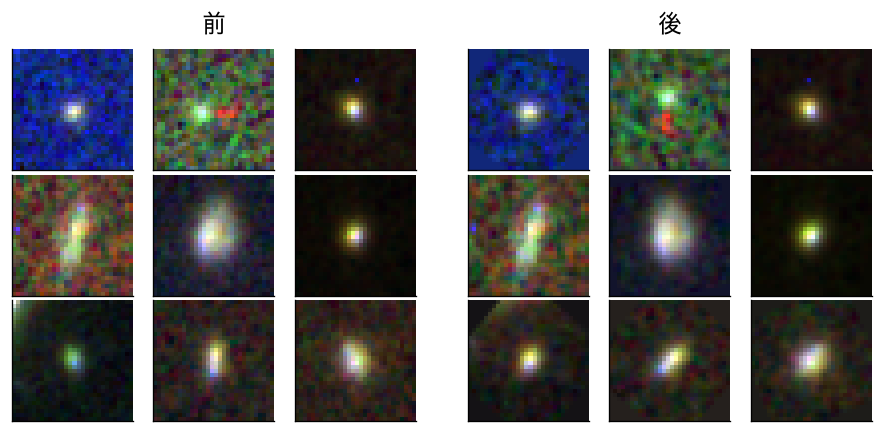

## 答え合わせ：46.3度

```
46.3
```

## 明るい画素の、散らばる向き

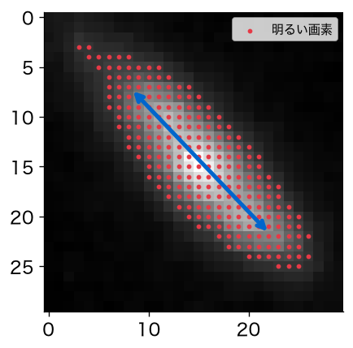

- 赤が明るい画素。青い矢印が第1主成分＝伸びている向き

## 答え合わせ：全部の銀河

```
43.8 89.8
```

- 角度の真ん中は、回転の前43.8度、後89.8度

## 回転の前と後で、向きは？

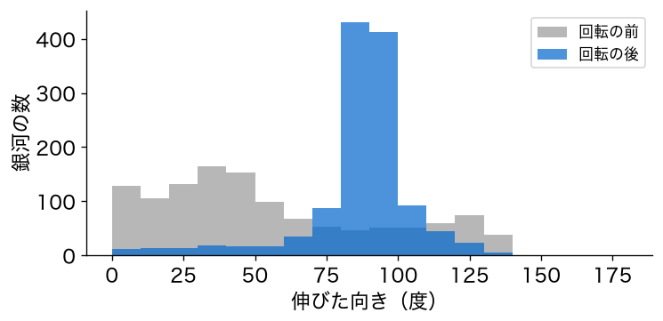

- 灰色が回転の前、青が回転の後

## 向きが、90度に集まる

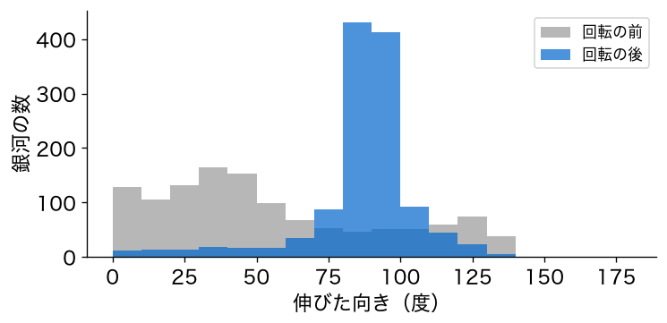

- 前はばらばら、後は縦（90度）に集まる
- 後は、全体の約7割が90度±10度に入る（前は1割未満）

## ここにも、PCA

- PCAは「データがいちばん散らばる向き」を探す道具（第9回）
- ここでは、画素の座標に使って、銀河の向きを測っている

# 4. PCAと固有銀河

## 2,700列の表に、PCA

- 前処理した1,222個 × 2,700列の表に、PCAをかける
- 主成分を30×30×3に戻すと、画像になる。これが固有銀河

## お手本：著者のPCAのセル

```python
print(author(11))
exec(author(11))
```

- 役割：寄与率の合計が96%になるまでの主成分を求め、得点を出す

## 答え合わせ：著者のPCA

```
pca=PCA(.96).fit(norm_data)
scores=pca.transform(norm_data)
lik=pca.score_samples(norm_data)
print(pca.n_components_)
10
```

## PCA(.96) の意味

- `n_components`に0〜1の数を渡すと、累積寄与率がこの割合に届くまでの数を選ぶ
- `score_samples`：5節で使う、ありそうさ

## 10個で、96%

- 1,222個の銀河の散らばりの96%を、10個の固有銀河で表せた
- 論文は約1万個で約12個。近い値

## 変えてみる：固有銀河を描く

```python
exec(author(24))
```

- 24番のセル：主成分を、3つの帯ごとに画像にして縦に並べる

## TODO③：90%には、何個？

```python
# TODO: 累積寄与率が初めて 0.9 以上になる主成分の数を求める
# ヒント: p = PCA().fit(norm_data)
#         cum = np.cumsum(p.explained_variance_ratio_)
#         np.argmax(cum >= 0.9) + 1
...
```

## お手本：組み立て直す

```python
for k in [2, 10, 50]:
    p = PCA(k).fit(norm_data)
    rec = p.inverse_transform(p.transform(norm_data[:9]))
    make_image_pre(rec, (3, 3), f'{k}個')
plt.show()
```

- `inverse_transform`：得点から、元の2,700列の形に戻す（第9回の再構成）

## やってみよう：4節とTODO③

- 4節のお手本と「変えてみる」のセルを実行する
- TODO③：90%を表すには、何個の固有銀河が要るか？

動画の人は、ここで一時停止。

## 答え合わせ：固有銀河1〜10

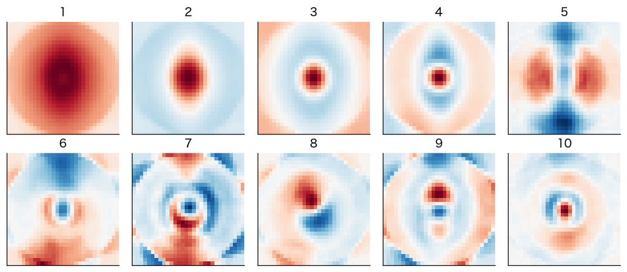

- 1つの帯（F125W）で、赤がプラス、青がマイナス

## 1つ目は、全体の明るさ

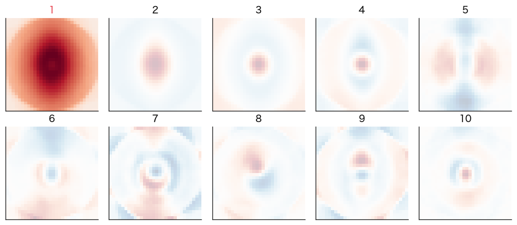

- 大きく広がった明るさ。銀河全体の明るさと大きさ

## 2つ目は、縦に伸びた中心

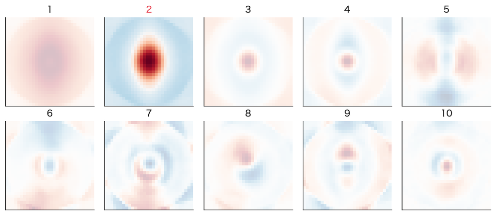

- 回転を縦にそろえたので、「縦に伸びているか」が2番目の違いに

## 3つ目は、中心への集まり

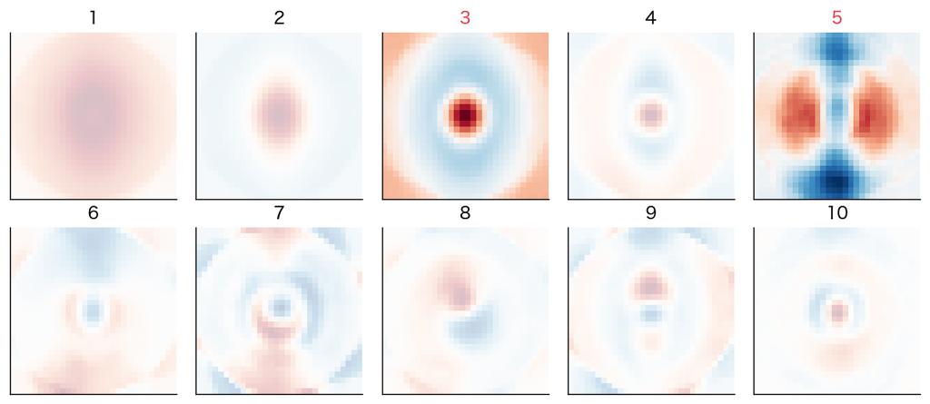

- 3：明るさが中心にどれだけ集まるか。5：縦と横の対比

## 後ろほど、細かい形

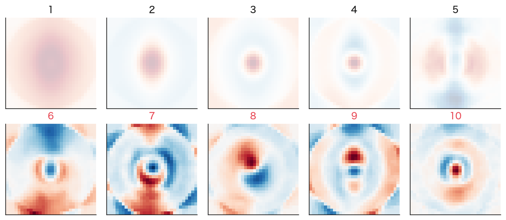

- 上下の片寄りのような、細かい形の違い

## 答え合わせ：TODO③

```
3
```

- 3個。第1主成分だけで76.3%

## 累積寄与率

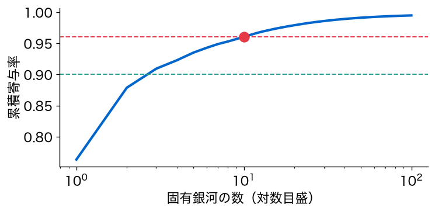

- 90%に3個、96%に10個、99%には45個

## ごく少ない固有銀河で、表せる

- 銀河の形のほとんどは、ごく少ない固有銀河の足し算で表せる
- 論文の主張どおり

## 答え合わせ：2個で組み立て直す

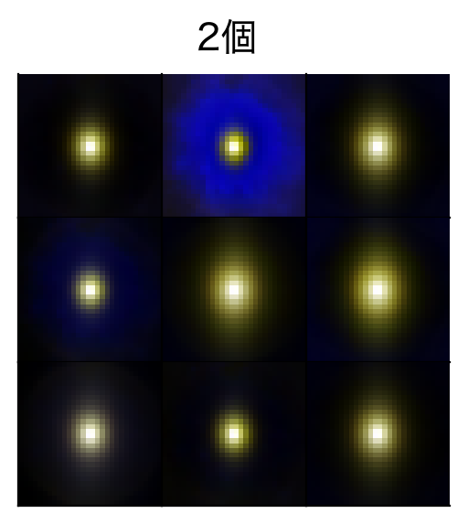

- ぼんやりした楕円

## 10個なら

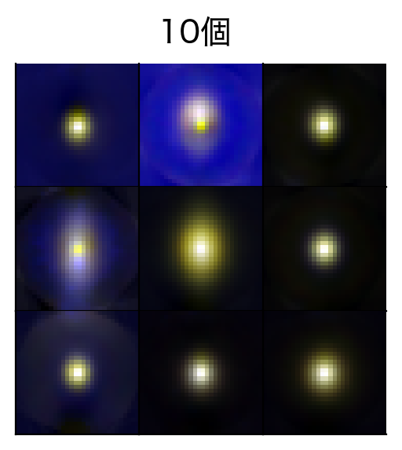

- 伸び方や、明るさの偏りまで戻る

# 5. 外れ値

## 10個で戻った。戻らないのは？

- 固有銀河の足し算で、うまく表せない銀河を探す

## めずらしい銀河を探す

- `score_samples`：PCAのつくる「ふつうの散らばり」に、どれくらいありそうか
- いちばん小さい銀河は、固有銀河では表しにくい、めずらしい形

## お手本：著者の外れ値のセル

```python
print(author(16))
exec(author(16))
plt.show()
```

- ありそうさの小さい順・大きい順に、25個ずつカラー画像を並べる
- `make_image`：名前に合うPNGを開いて並べる関数（7番のセル）

## やってみよう：5節

- 5節のお手本のセルを実行する
- めずらしい銀河と、ありふれた銀河は、どう違うか？

動画の人は、ここで一時停止。

## めずらしい25個

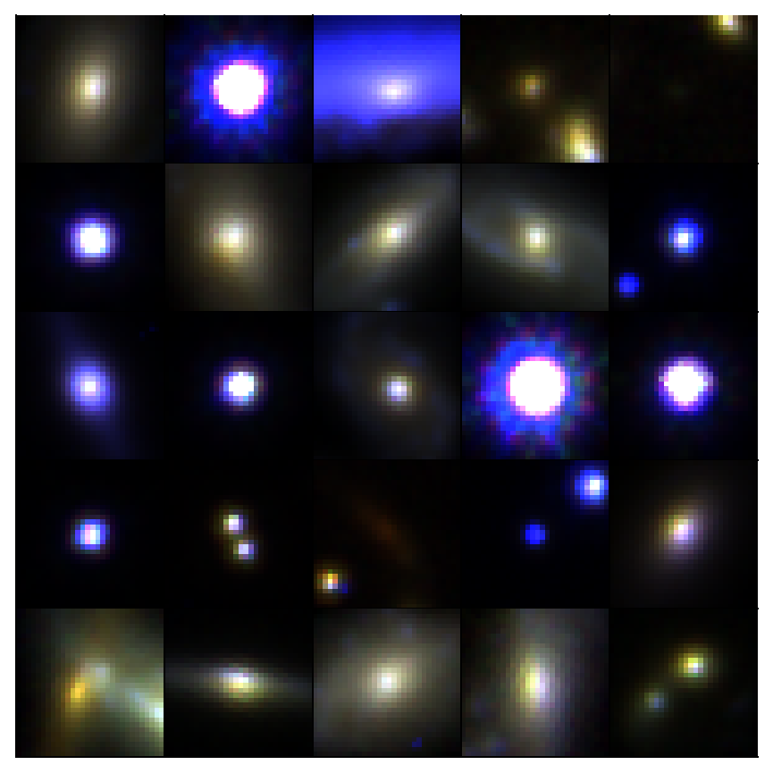

## 写りこみや、重なり

- とても明るく青い点（星が写りこんだのかも）
- 2つ以上が1枚に写ったもの、大きく広がった明るい銀河

## ありふれた25個

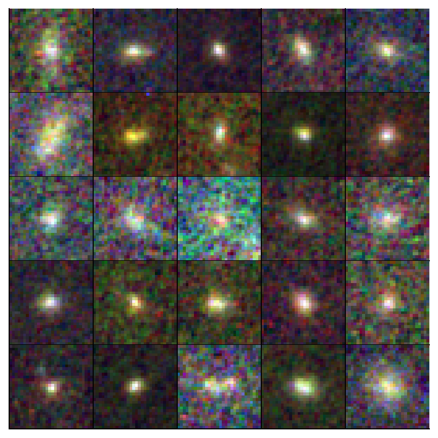

- 小さく暗い銀河ばかり。背景のざらつきが目立つ

## 外れ値は、汚れも見つける

- めずらしい銀河だけでなく、データの汚れ（写りこみ・重なり）も見つかる

# 6. クラスタリング

## 外れ値は見た。似た銀河は？

- ノートの最後のブロック、33番のセルへ

## Affinity Propagation

- 固有銀河の得点で、似た形の銀河を集める
- k-meansと違って、グループの数を先に決めない

## 代表を、推しあう

- 各点が「自分の代表にふさわしい点」を互いに推しあう
- 代表と、そこに集まるグループが決まる

## お手本：著者のクラスタリング

```python
print(author(33))
exec(author(33))
sizes = pd.Series(clust.labels_).value_counts()
print(len(sizes), 'グループ')
print(sizes.head(5).values)
```

- `value_counts()`：値ごとの数を、多い順に並べる

## 変えてみる：最大のグループ

```python
top = indexes[clust.labels_ == sizes.index[0]]
make_image(top[:30], (5, 6))
plt.show()
```

## おさらい：条件で絞る

```python
df[df['price'] <= 100000]      # 10万円以下の部屋だけ
```

- `[ ]`にTrue/Falseの並びを入れると、Trueの所だけが残る（第3回）
- `clust.labels_ == 番号`で、そのグループの銀河だけを取り出す

## TODO④：2番目のグループ

```python
# TODO: 2番目に大きいグループの先頭30個を、画像で並べる
# ヒント: お手本の sizes.index[0] を sizes.index[1] に変える
...
```

## やってみよう：6節とTODO④

- 6節のお手本と「変えてみる」のセルを実行する
- TODO④：2番目に大きいグループは、どんな形か？

動画の人は、ここで一時停止。

## 答え合わせ：約145のグループ

```
145 グループ
[143 141 110  97  93]
```

- 大きいグループは143・141・110・97個。1個だけのグループもたくさん

## グループの数が、揺れる

- 実行するたびに、グループの数が少し揺れる（145〜147ほど）
- 著者のセルは、乱数の種を決めていない。大きいグループの顔ぶれは、ほぼ同じ

## いちばん大きいグループ

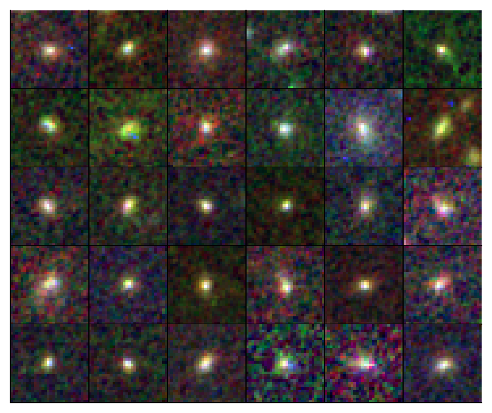

- 小さく丸い、中心の明るい銀河

## 答え合わせ：TODO④

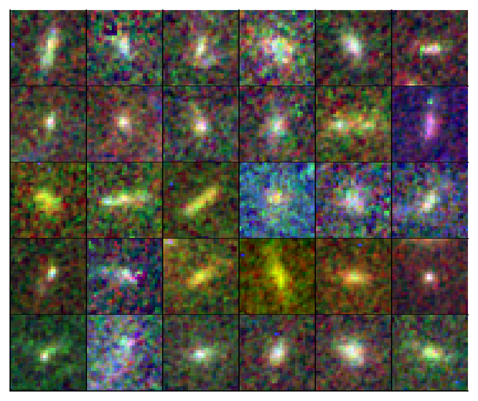

- 細長く伸びた銀河が中心

## PNGは、回転の前

- 並べたカラー画像は回転する前なので、伸びる向きはばらばら
- 回転をそろえてからPCAをかけたので、「伸びているか」がグループの違いに

## 先輩への答え

論文の主張は、手元の1,222個でも確かめられた。前処理のあと、10個の固有銀河で96%を表せ（論文は約12個）、丸い銀河・細長い銀河などのグループに分けられる。

## 揺れる所に、気をつける

- ファイルの並び順と、乱数の種で、結果が揺れる所がある
- 再現するときは、並べ方をそろえ、揺れを確かめる

## まだ言えないこと①：前処理

- 回転をそろえる段がなかったら、固有銀河の数はどう変わるか（課題）

## まだ言えないこと②：グループの数

- 約145は、多すぎないか
- 分け方の良し悪しを、数で測るには

# まとめ

## 今日の歩み

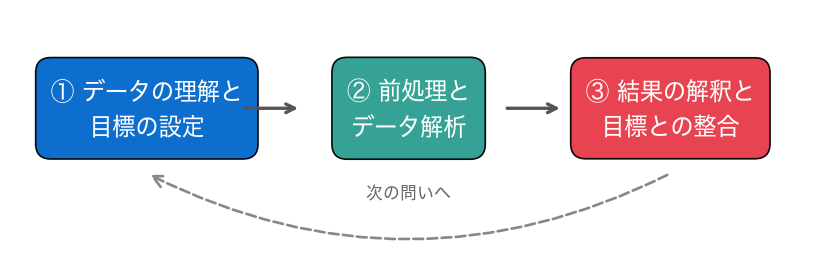

地図を描く → 形式ごとに読む → 前処理 → PCA → 外れ値 → クラスタリング

## 今日の要点

- 他人のコードは、見出しと関数のまとまりで地図を描いてから、ブロックごとに読む
- `.ipynb`はJSON。辞書とリストの入れ子として読める
- .npyは`np.load`、PNGは`plt.imread`。たくさんのファイルは`glob`
- パイプライン：読み込み → クリップ → 回転（座標にPCA） → PCA → 外れ値 → クラスタリング
- 再現では、並び順や乱数の種のように、結果が揺れる所に気をつける

## 課題の出し方

- ノートの最後の「課題（提出）」に取り組む
- 応用②の答えと応用③の文章を、LACSに入力して提出（＝出席。期限なし）
- AIを使ってもよい。何を聞いて、どう直したかを1行書く

## 次回予告：グループの数

- 今日は約145、第11回はK＝3。どちらも、その数でよいかは確かめていない
- 次回は、分け方の良し悪しを数で測る

## 次回の問い

その分け方は、妥当か？グループの数をいくつにすべきか、根拠をもって言えるか？

## このあと：課題へ

ノートの「課題（提出）」へ。回転をそろえる段を外すと、固有銀河の数はどう変わるか。